# Multiple testing

Peter Ralph

27 October – Advanced Biological Statistics

# Multiple comparisons

## A silly example

Suppose 100 people did 100 well-executed experiments to ask if snails move faster while listening to metal than to mozart.

How many would find a statistically significant difference at $p < 0.05$?

Would any find a large effect size?

## A less silly example

Suppose someone conducts a well-controlled study that records the salary and the mean daily consumption of 100 different foods in a bunch of people.

How many of the foods would be statistically significantly correlated with income at $p < 0.05$?

Would any have a large effect size?

## The problem

A $p$-value is

> the probability of seeing something at least as extreme as what was seen in the data, if the null hypothesis were true.

So, if the null hypothesis *is* true, then **by definition**, $p$-values are uniformly distributed between 0 and 1.

## The Bonferroni Correction

A cutoff of $p < 0.05$ ensures you should not wrongly reject the null hypothesis more than 5% of the time.

But, if you do $n$ different tests, all at once?

To tolerate *some* errors, use the *false discovery rate*.

## Example: Bonferroni

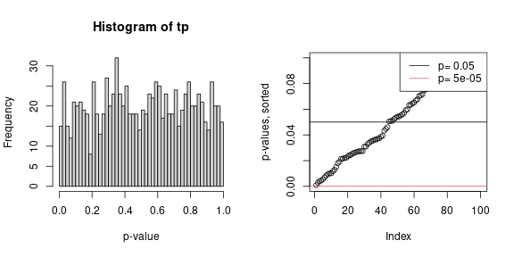

```r
tp <- replicate(1000, t.test(rnorm(20))$p.value)
layout(t(1:2))
hist(tp, breaks=40, xlab='p-value')
plot(sort(tp), xlim=c(1,100), ylim=c(0, 0.1), ylab='p-values, sorted')
abline(h=c(0.05, 0.05/length(tp)), col=1:2)
legend("topright", lty=1, col=1:2, legend=paste("p=", c(0.05, 0.05/length(tp))))
```

## Example: False Discovery Rate

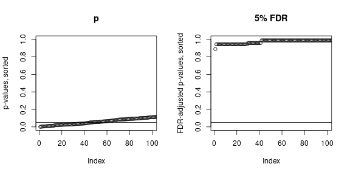

```r
layout(t(1:2))
plot(sort(tp), xlim=c(1,100), ylim=c(0, 1.0), ylab='p-values, sorted', main='p')
abline(h=0.05, col=1:2)
plot(sort(p.adjust(tp, method='fdr')), xlim=c(1,100), ylim=c(0, 1.0), ylab='FDR-adjusted p-values, sorted', main='5% FDR')
abline(h=0.05, col=1:2)
```

# Many regressions

## Gene expression levels

From [*Host Genotype and Microbiota Contribute Asymmetrically to Transcriptional Variation in the Threespine Stickleback Gut* Clayton M. Small, Kathryn Milligan-Myhre, Susan Bassham, Karen Guillemin, William A. Cresko. Genome Biology and Evolution, March 2017.](https://academic.oup.com/gbe/article/9/3/504/3058199)

- Metadata: CVvsGF_RNAseq_Metadata.tsv
- RNA-Seq: CVvsGF_RNAseq_CPM.tsv

## The data

```r
fish <- read.table("../Datasets/stickleback_GFvsCV_RNAseq/CVvsGF_RNAseq_Metadata.tsv", header=TRUE, sep='\t')
tmp <- read.table("../Datasets/stickleback_GFvsCV_RNAseq/CVvsGF_RNAseq_CPM.tsv", header=TRUE, sep='\t', stringsAsFactors=FALSE, check.names=FALSE)
genes <- tmp[,1:5]
expression <- as.matrix(tmp[,6:ncol(tmp)])
# sanity check
stopifnot(all(match(colnames(expression), fish$Individual) == 1:nrow(fish)))
```

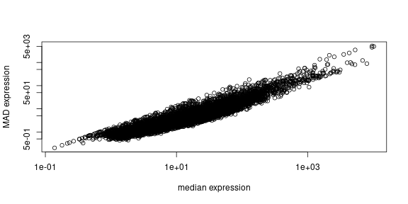

## Normalize

To put coefficients on the same scale:

```r
expr <- sweep(expression, 1, rowMeans(expression), "/")
```

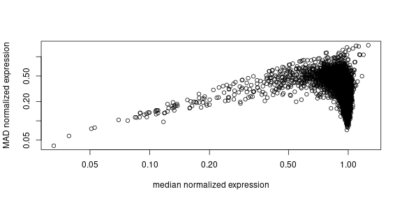

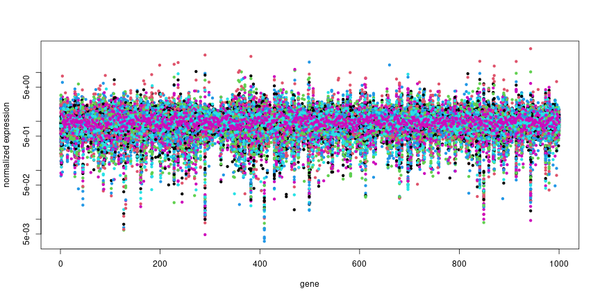

```r
matplot(expr[1:1000,], pch=20, log='y', xlab='gene', ylab='normalized expression')
```

Fit *lots* of models:

```r
pop_lms <- apply(expr, 1, function (x) (lm(x ~ Population, data=fish)))
all_lms <- apply(expr, 1, function (x) (lm(x ~ Population + Treatment + Sex, data=fish)))
anovas <- mapply(anova, pop_lms, all_lms, SIMPLIFY=FALSE)
```

and extract coefficients, $p$-values

```r
pop_coefs <- sapply(pop_lms, coef)
all_coefs <- sapply(all_lms, coef)
pvals <- sapply(lapply(anovas, "[[", "Pr(>F)"), "[", 2)
```

## The $p$-values

… for an ANOVA comparing

```
    gene expression ~ Population
    gene expression ~ Population + Treatment + Sex
```

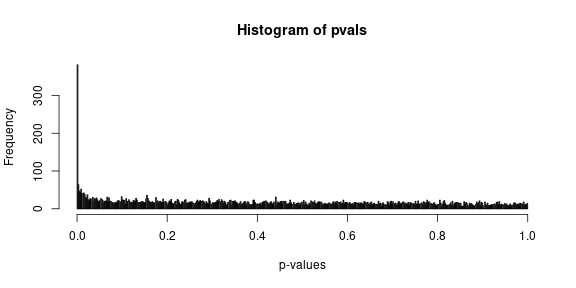

```r
hist(pvals, breaks=500, xlab='p-values')
```

Coefficents, with $p < 0.05$ in red:

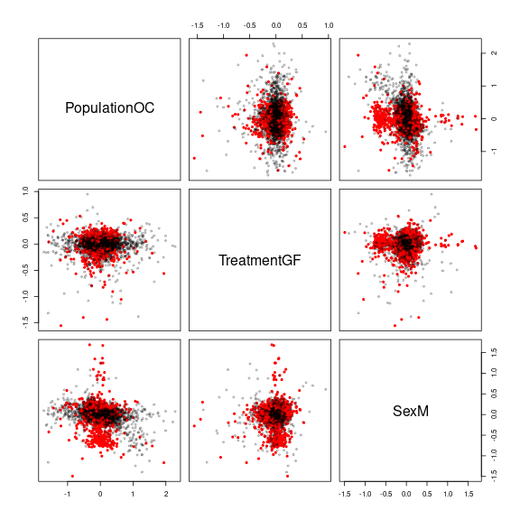

Coefficents, with $p < 0.05/n$ in red:

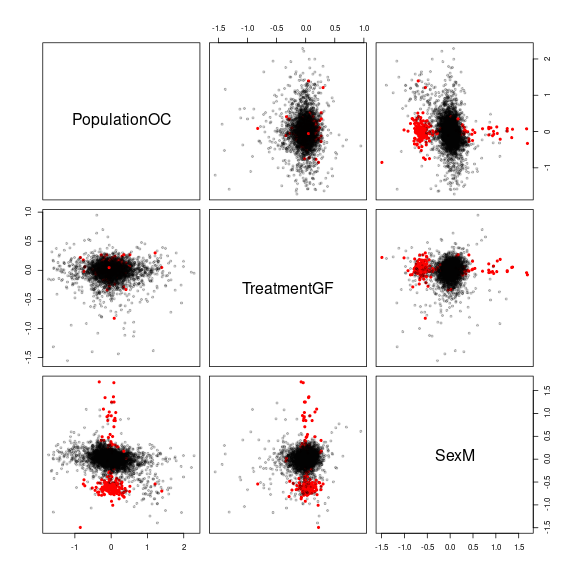

## The Bonferroni Bunch

```r
subset(genes, pvals < 0.05/nrow(genes))
```

```
##                 Gene_ID   Genome_Loc Gene_Start_bp                                                                                                                       Gene_Description
## 379  ENSGACG00000001729 scaffold_882          1249                                                                   *interleukin-8 [Lateolabrax japonicus];ABI48894 [Source:TopBlasxHit]
## 594  ENSGACG00000002048     groupXXI       2362051                                                       RNA-binding region (RNP1, RRM) containing 3 [Source:ZFIN;Acc:ZDB-GENE-060312-35]
## 833  ENSGACG00000002397       groupV        842100                                                                         stearoyl-CoA desaturase b [Source:ZFIN;Acc:ZDB-GENE-050522-12]
## 985  ENSGACG00000003874     groupXIX       5074262                                                                                    parvin, beta [Source:ZFIN;Acc:ZDB-GENE-030131-4411]
## 1005 ENSGACG00000003899     groupXIX       5087963                                                                                     parvin, gamma [Source:ZFIN;Acc:ZDB-GENE-070410-67]
## 1014 ENSGACG00000003911     groupXIX       5234537                                                                                         plexin b2b [Source:ZFIN;Acc:ZDB-GENE-080902-1]
## 1028 ENSGACG00000003928     groupXIX       5268421                                                        tubulin, gamma complex associated protein 6 [Source:HGNC Symbol;Acc:HGNC:18127]
## 1042 ENSGACG00000003947     groupXIX       5289965            adaptor protein, phosphotyrosine interaction, PH domain and leucine zipper containing 2 [Source:ZFIN;Acc:ZDB-GENE-081016-2]
## 1102 ENSGACG00000004020     groupXIX       5466205                                                                       transmembrane protein 117 [Source:ZFIN;Acc:ZDB-GENE-040426-2809]
## 1109 ENSGACG00000004028     groupXIX       5497683                                                                   twinfilin actin-binding protein 1 [Source:HGNC Symbol;Acc:HGNC:9620]
## 1128 ENSGACG00000004050     groupXIX       5505366                                                       interleukin-1 receptor-associated kinase 4 [Source:ZFIN;Acc:ZDB-GENE-040426-738]
## 1138 ENSGACG00000004063     groupXIX       5536933                                         ADAM metallopeptidase with thrombospondin type 1 motif, 20 [Source:HGNC Symbol;Acc:HGNC:17178]
## 1155 ENSGACG00000004088     groupXIX       5663914                                                                    prickle homolog 1a (Drosophila) [Source:ZFIN;Acc:ZDB-GENE-030724-5]
## 1161 ENSGACG00000004098     groupXIX       5670651                                                                                       periphilin 1 [Source:HGNC Symbol;Acc:HGNC:19369]
```

[output cut: 439 more lines]

## The paper

> We limited differential expression analysis to only those genes represented by at least two reads per million mapped (“copies per million,” CPM) in at least 12 of the 84 libraries (see supplementary fig. S1, Supplementary Material online). We normalized read counts for these 15,847 genes using TMM normalization (Robinson and Oshlack 2010) as implemented by the calcNormFactors function of the R/Bioconductor package edgeR (Robinson et al. 2010). In order to perform gene-wise differential expression analyses in a general linear model framework (Law et al. 2014), we supplied the TMM normalization factors to the voom function of the R/Bioconductor package limma (Ritchie et al. 2015), which generated appropriately weighted log2CPM expression values for all observations. We then fit a linear model for each gene including the fixed effects of factor levels for host population, host family (nested within host population), sex, and microbiota treatment using the limma lmFit function. We did not include a library “batch” effect in the model because initial nMDS ordination did not suggest batch as a major source of transcriptional variation, and our stratified assignment of samples to batches controlled for any confounding effect of batch with respect to other factors of interest. To account for variation between replicate flasks we incorporated flask as a random effect in the model using the limma duplicateCorrelation function. Each hypothesis of interest was tested, for each gene, using one or more contrasts via moderated t-tests applied by the limma function eBayes. To evaluate the effect of our microbiota treatment we performed a within-OC contrast, a within-FW contrast, and an overall contrast. Genes expressed differentially in any of these three contrasts were interpreted as being associated with the presence of microbes. We performed a single contrast to test for an overall effect of host population, and a single contrast to test for an interaction between host population and microbiota, both of these accounting for family differences nested within population. Finally, we performed contrasts to test for an effect of sex and a sex-by-microbiota interaction. For each of these seven contrasts, we controlled the false discovery rate (FDR) at 0.1 using the approach of Benjamini and Hochberg (1995), as implemented by the limma topTable function.